# covid-age-demo

2023-08-25

This markdown provides a quick demo on how to set up and run `covid-age` simulation. The simulation code is written in `c++`. To compile, run the following commands

```bash
$ git clone git@github.com:NSF-RESUME/covid-age.git
$ cd ./source
$ make Utility.o
$ cd ../exp/chicago_yr1/
$ make model
```

This should produce an executable `model` in the `./exp/chicago_yr1/` directory. To run the model from command line

```bash
$ ./model
```

#### Parameters

The parameters and their types are listed below:

- `output_directory` - string
- `output_filename` - string
- `nmtr_Kasymp` - float
- `nmtr_Kmild` - float
- `ini_Ki` - float
- `frac_infectiousness_As` - float
- `frac_infectiousness_det` - float
- `duration` - integer
- `print_params` - boolean
- `Ki_ap` - json
- `random_seeds` - json
- `save_to` - string
- `restore_from` - string
- `restore_seed` - integer

### Running simulation in R

`covid_age_wrapper.R` provides an R function to run the simulation within an R session. The inputs are passed as a names list to the function with the same input parameter names as listed above. The json inputs are passed as a matrix, examples of which are provided below.

```r
source("../R/covid_age_wrapper.R")

covid_model <- "/home/afadikar/work/projects/git/covid-age/exp/chicago_yr1/model"
par_list <- list("random_seeds" = rbind(c(0, 1)),
                 "ini_Ki" = 0.97,
                 "Ki_ap" = rbind(c(0, 1), c(28, 0.7), c(50, 0.3), c(60, 1)),
                 "output_directory" = "/home/afadikar/temp",
                 "output_filename" = paste0("out_", sample(1e9, 1), ".out"),
                 "duration" = 100)
d <- run_covid_age(covid_model, par_list)

knitr::kable(head(d))
```

| node | time | Ki | S | E | AP | SYM | HOS | CRIT | DEA | R | cumu_sym | cumu_adm | introduced |
| --- | --- | --- | --- | --- | --- | --- | --- | --- | --- | --- | --- | --- | --- |
| 0 | 9 | 0.97 | 2499990 | 10 | 0 | 0 | 0 | 0 | 0 | 0 | 0 | 0 | 0 |
| 0 | 10 | 0.97 | 2499989 | 9 | 1 | 1 | 0 | 0 | 0 | 0 | 1 | 0 | 0 |
| 0 | 11 | 0.97 | 2499988 | 10 | 1 | 1 | 0 | 0 | 0 | 0 | 1 | 0 | 0 |
| 0 | 12 | 0.97 | 2499986 | 10 | 3 | 1 | 0 | 0 | 0 | 0 | 1 | 0 | 0 |
| 0 | 13 | 0.97 | 2499977 | 15 | 6 | 2 | 0 | 0 | 0 | 0 | 2 | 0 | 0 |
| 0 | 14 | 0.97 | 2499972 | 18 | 8 | 2 | 0 | 0 | 0 | 0 | 2 | 0 | 0 |

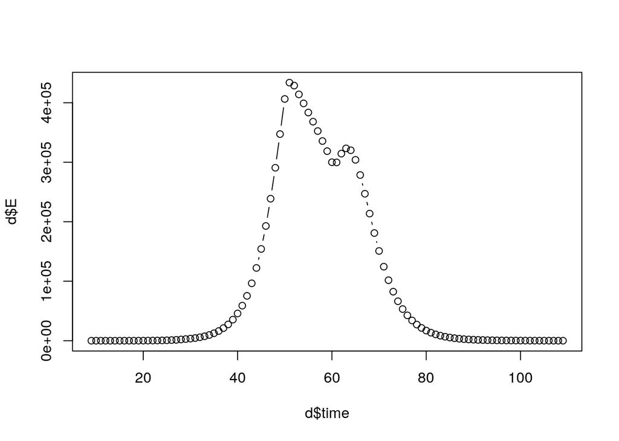

```r
plot(d$time, d$E, type = "b")
```

#### Time varying parameters

There are two time varying inputs to the model, `Ki_ap` and `random_seeds`. The values of these parameters are passed as a two-column matrix, where the first column contains the day indices where the value changes and the second column contains the values of the parameter.

```r
Ki_ap = rbind(c(0, 1), c(28, 0.7), c(50, 0.3), c(60, 1))
random_seeds = rbind(c(0, 1), c(28, 2), c(60, 3))

Ki_ap
```

```
##      [,1] [,2]
## [1,]    0  1.0
## [2,]   28  0.7
## [3,]   50  0.3
## [4,]   60  1.0
```

```r
random_seeds
```

```
##      [,1] [,2]
## [1,]    0    1
## [2,]   28    2
## [3,]   60    3
```

#### Checkpointing

To checkpoint a model, `save_to` parameter needs to be specified with full path of the checkpointed file. Similarly, to restore and simulate from a checkpointed model, `restore_from` should be used.

```r
## checkpoint after 50 days
par_list <- list("random_seeds" = rbind(c(0, 1)),
                 "ini_Ki" = 0.97,
                 "Ki_ap" = rbind(c(0, 1), c(28, 0.7), c(50, 0.3), c(60, 1)),
                 "output_directory" = "/home/afadikar/temp",
                 "output_filename" = paste0("out_", sample(1e9, 1), ".out"),
                 "duration" = 50,
                 "save_to" = "/home/afadikar/temp/covid-age-checkpoint")
d_before_checkpoint <- run_covid_age(covid_model, par_list)

## resrote from checkpointed model
par_list <- list("random_seeds" = rbind(c(0, 1)),
                 "ini_Ki" = 0.97,
                 "Ki_ap" = rbind(c(0, 1), c(28, 0.7), c(50, 0.3), c(60, 1)),
                 "output_directory" = "/home/afadikar/temp",
                 "output_filename" = paste0("out_", sample(1e9, 1), ".out"),
                 "duration" = 50,
                 "restore_from" = "/home/afadikar/temp/covid-age-checkpoint")
d_after_checkpoint <- run_covid_age(covid_model, par_list)
```

Now check whether we get back the expected outcome from checkpointing.

```r
dt <- data.table(time = d$time, E = d$E)
dt <- merge(dt, d_before_checkpoint[, .(time, E)], all.x = T, by = "time")
colnames(dt)[2:3] <- c("full_run", "pre_check")

dt <- merge(dt, d_after_checkpoint[, .(time, E)], all.x = T, by = "time")
colnames(dt)[4] <- "post_check"

rmarkdown::paged_table(dt)
```

| time | full_run | pre_check | post_check |
| --- | --- | --- | --- |
| 9 | 10 | 10 | NA |
| 10 | 9 | 9 | NA |
| 11 | 10 | 10 | NA |
| 12 | 10 | 10 | NA |
| 13 | 15 | 15 | NA |
| 14 | 18 | 18 | NA |
| 15 | 25 | 25 | NA |
| 16 | 33 | 33 | NA |
| 17 | 40 | 40 | NA |
| 18 | 68 | 68 | NA |

[output cut: 91 more lines]

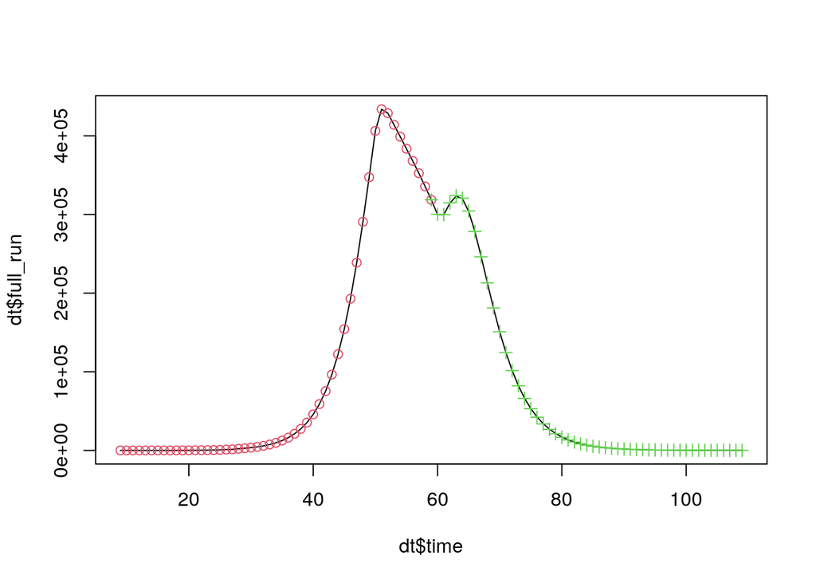

```r
plot(dt$time, dt$full_run, col = 1, type = "l")
points(dt$time, dt$pre_check, col = 2, pch = 1)
points(dt$time, dt$post_check, col = 3, pch = 3)
```